# Data Analysis 1: dplyr and UNC departments

STOR 320

# Amanda Liu PID: 730042603

Due **Monday 9/11/17** before the start of class.

**You are to work alone on this assignment. (We will discuss.)**

Universities are typically opaque, bureaucratic institutions. Many public schools such as the University of North Carolina system make [data about university employees publically](http://www.newsobserver.com/news/databases/public-salaries/) available. Using this dataset what can we learn about the dynamics of the university system?

## dplyr

To download the RMarkdown file for this assignment, right-click on [.Rmd file for this assignment](https://www.dropbox.com/s/h18er3ap1v7w29k/Data%20Analysis%201.Rmd?dl=0), and select *open link in new tab*. Then proceed to download by saving the file to your *Working Directory*

The best way to to learn the dplyr package is to just use it a lot. Read through the following dplyr tutorial the complete questions in this .Rmd document. I suggest doing the coding in an R script then putting the answers into this documents.

## Instructions

- Please attempt these questions by Monday, September 11 at 4:40. The graded version will be turned in on September 13, but it is essential that you make a serious attempt at Questions 1-10 by Monday.
- use `dplyr` functions to answer the following questions (base R will not be given credit)
- submit a zipped folder containing the .Rmd file and the associated .html file to Sakai.
- When you are given directions, **return** something means just print it out. Similarly for questions **What is …** just print out the answer.

Q: Return the sum of the first 10 positive integers?

Q: What is the sum of the first 10 positive integers?

```r
sum(1:10)
```

```
## [1] 55
```

- **create** or **save** means save a variable

Create a variable `x` with the sum of the first 10 positive integers.

```r
x <- sum(1:10)
```

# The data

First download the data set from Ryan Thornburg’s website. You may want to set `cache=TRUE` for this chunk so you don’t have to download the data set every time you run the script.

```r
library(tidyverse)
library(lubridate)

# Load the UNC departments data
data <- read_csv(url("http://ryanthornburg.com/wp-content/uploads/2015/05/UNC_Salares_NandO_2015-05-06.csv"))
```

Take a first look at the data

```r
colnames(data)
```

```
##  [1] "name"     "campus"   "dept"     "position" "exempt2"  "employed"
##  [7] "hiredate" "fte"      "status"   "stservyr" "statesal" "nonstsal"
## [13] "totalsal" "age"
```

```r
str(data)
```

```
## Classes 'tbl_df', 'tbl' and 'data.frame':    12287 obs. of  14 variables:
##  $ name    : chr  "AARON, NANCY G" "ABARBANELL, JEFFERY S" "ABARE, BETSY" "ABATE, AARON B" ...
##  $ campus  : chr  "UNC-CH" "UNC-CH" "UNC-CH" "UNC-CH" ...
##  $ dept    : chr  "Romance Languages" "Kenan-Flagler Business School" "Institute of Marine Sciences" "Medicine Administration" ...
##  $ position: chr  "Senior Lecturer" "Associate Professor" "Research Technician" "Accounting Technician" ...
##  $ exempt2 : chr  "Exempt" "Exempt" "Subject to State Personnel Act" "Subject to State Personnel Act" ...
##  $ employed: int  9 9 12 12 12 12 12 12 12 12 ...
##  $ hiredate: int  20030701 19990101 20110912 20090420 20120103 20051003 19960923 20130401 19870101 20120702 ...
##  $ fte     : num  1 1 1 1 1 1 1 1 1 1 ...
##  $ status  : chr  "Fixed-Term" "Continuing" "Permanent" "Permanent" ...
##  $ stservyr: int  11 17 3 5 2 15 34 11 27 2 ...
##  $ statesal: int  46350 173000 0 0 41696 56588 41707 0 0 0 ...
##  $ nonstsal: int  0 0 38170 50070 0 4412 0 80227 55803 32889 ...
##  $ totalsal: int  46350 173000 38170 50070 41696 61000 41707 80227 55803 32889 ...
##  $ age     : int  55 57 54 29 35 41 62 36 64 26 ...
##  - attr(*, "spec")=List of 2
##   ..$ cols   :List of 14
##   .. ..$ name    : list()
##   .. .. ..- attr(*, "class")= chr  "collector_character" "collector"
##   .. ..$ campus  : list()
##   .. .. ..- attr(*, "class")= chr  "collector_character" "collector"
##   .. ..$ dept    : list()
##   .. .. ..- attr(*, "class")= chr  "collector_character" "collector"
##   .. ..$ position: list()
##   .. .. ..- attr(*, "class")= chr  "collector_character" "collector"
##   .. ..$ exempt2 : list()
##   .. .. ..- attr(*, "class")= chr  "collector_character" "collector"
##   .. ..$ employed: list()
##   .. .. ..- attr(*, "class")= chr  "collector_integer" "collector"
##   .. ..$ hiredate: list()
##   .. .. ..- attr(*, "class")= chr  "collector_integer" "collector"
##   .. ..$ fte     : list()
##   .. .. ..- attr(*, "class")= chr  "collector_double" "collector"
##   .. ..$ status  : list()
##   .. .. ..- attr(*, "class")= chr  "collector_character" "collector"
##   .. ..$ stservyr: list()
##   .. .. ..- attr(*, "class")= chr  "collector_integer" "collector"
##   .. ..$ statesal: list()
##   .. .. ..- attr(*, "class")= chr  "collector_integer" "collector"
##   .. ..$ nonstsal: list()
##   .. .. ..- attr(*, "class")= chr  "collector_integer" "collector"
##   .. ..$ totalsal: list()
##   .. .. ..- attr(*, "class")= chr  "collector_integer" "collector"
##   .. ..$ age     : list()
##   .. .. ..- attr(*, "class")= chr  "collector_integer" "collector"
##   ..$ default: list()
##   .. ..- attr(*, "class")= chr  "collector_guess" "collector"
##   ..- attr(*, "class")= chr "col_spec"
```

```r
head(data)
```

```
## # A tibble: 6 x 14
##                        name campus                          dept
##                       <chr>  <chr>                         <chr>
## 1            AARON, NANCY G UNC-CH             Romance Languages
## 2     ABARBANELL, JEFFERY S UNC-CH Kenan-Flagler Business School
## 3              ABARE, BETSY UNC-CH  Institute of Marine Sciences
## 4            ABATE, AARON B UNC-CH       Medicine Administration
## 5        ABATEMARCO, JODI M UNC-CH           School of Education
## 6 ABBOTT-LUNSFORD, SHELBY L UNC-CH       Medicine Administration
## # ... with 11 more variables: position <chr>, exempt2 <chr>,
## #   employed <int>, hiredate <int>, fte <dbl>, status <chr>,
## #   stservyr <int>, statesal <int>, nonstsal <int>, totalsal <int>,
## #   age <int>
```

# Assignment

## Question 1

Return a data frame with columns: name, dept, age,totalsal

```r
select(data, name, dept, age, totalsal)
```

```
## # A tibble: 12,287 x 4
##                         name                          dept   age totalsal
##                        <chr>                         <chr> <int>    <int>
##  1            AARON, NANCY G             Romance Languages    55    46350
##  2     ABARBANELL, JEFFERY S Kenan-Flagler Business School    57   173000
##  3              ABARE, BETSY  Institute of Marine Sciences    54    38170
##  4            ABATE, AARON B       Medicine Administration    29    50070
##  5        ABATEMARCO, JODI M           School of Education    35    41696
##  6 ABBOTT-LUNSFORD, SHELBY L       Medicine Administration    41    61000
##  7        ABBOTTS, WILLIAM C                       Biology    62    41707
##  8         ABDOULAYI, SARA M    Carolina Population Center    36    80227
##  9           ABDULLAH, LUBNA    Cys Fibrosis/Pulmonary Res    64    55803
## 10                ABE, PAIGE         Housing Res Education    26    32889
## # ... with 12,277 more rows
```

Return a data frame with columns: statesal, nonstsal,totalsal using one of the `select_helpers` functions. If needed, google ‘select_helpers in R’.

```r
select(data, contains("sal"))
```

```
## # A tibble: 12,287 x 3
##    statesal nonstsal totalsal
##       <int>    <int>    <int>
##  1    46350        0    46350
##  2   173000        0   173000
##  3        0    38170    38170
##  4        0    50070    50070
##  5    41696        0    41696
##  6    56588     4412    61000
##  7    41707        0    41707
##  8        0    80227    80227
##  9        0    55803    55803
## 10        0    32889    32889
## # ... with 12,277 more rows
```

## Question 2

Rename the `fte` column to `fulltime`. Make sure this change is saved (i.e. `data <- ...`).

```r
data <- rename(data, fulltime = fte)
```

## Question 3

What is the mean salary in the Neurosurgery department?

```r
group_by(data, dept) %>%summarise(mean(totalsal)) %>%filter(dept == "Neurosurgery")
```

```
## # A tibble: 1 x 2
##           dept `mean(totalsal)`
##          <chr>            <dbl>
## 1 Neurosurgery         380058.1
```

Return a data frame with employee’s in the Neurosurgery department making more than $500,000. Why might these professors be so well paid?

```r
filter(data, dept == "Neurosurgery", totalsal >= 500000)
```

```
## # A tibble: 6 x 14
##                    name campus         dept                     position
##                   <chr>  <chr>        <chr>                        <chr>
## 1    CAMPBELL, DENNIS M UNC-CH Neurosurgery  Adjunct Assistant Professor
## 2       CARSON, LARRY V UNC-CH Neurosurgery           Clinical Professor
## 3      EWEND, MATTHEW G UNC-CH Neurosurgery                     DIRECTOR
## 4     JAUFMANN, BRUCE P UNC-CH Neurosurgery Clinical Associate Professor
## 5 KILPATRICK, MICHAUX R UNC-CH Neurosurgery Clinical Assistant Professor
## 6        WADON, CAROL M UNC-CH Neurosurgery Clinical Associate Professor
## # ... with 10 more variables: exempt2 <chr>, employed <int>,
## #   hiredate <int>, fulltime <dbl>, status <chr>, stservyr <int>,
## #   statesal <int>, nonstsal <int>, totalsal <int>, age <int>
```

```
First, they are all full-time. And in general, people who works in neurosurgery earn a lot.
```

## Question 4

What is the total amount that full time Dermatology employees get paid?

```r
filter(data, dept == "Dermatology", fulltime == 1)$totalsal %>% sum
```

```
## [1] 5272098
```

## Question 5

Create a data frame called radio_dept whose rows are the employees from the Radiology department.

- include only the following columns: name, position, age, nonstsal, totalsal.
- order the employees by salary

First without pipes

```r
radio_dept <- arrange(select(filter(data, dept == "Radiology"), name, position, age, nonstsal, totalsal), desc(totalsal))
```

Next with pipes

```r
radio_dept <- filter(data, dept == "Radiology") %>% select(name, position, age, nonstsal, totalsal) %>% arrange(desc(totalsal))
```

Make a histogram of Radiology salaries

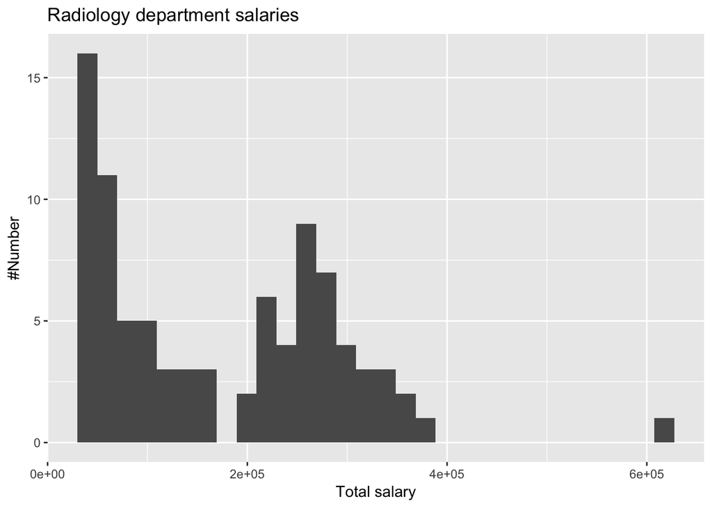

```r
ggplot(radio_dept) + geom_histogram(mapping = aes(x = totalsal),bins = 30) + xlab("Total salary")+ ylab("#Number") + ggtitle("Radiology department salaries")
```

## Question 6

Create a data frame called `dept_summary` whose rows are the departments and whose columns are: department size, mean department salary, median department salary, and maximum salary (using totalsal for salary).

```r
dept_summary <- group_by(data, dept) %>%summarise(dept_size = n(), mean_dept_totalsal = mean(totalsal), med_dept_totalsal = median(totalsal), max_dept_totalsal = max(totalsal))
```

Order the departments by highest mean salary and print the 10 highest paid departments.

```r
dept_summary %>%arrange(desc(mean_dept_totalsal)) %>%select(dept)
```

```
## # A tibble: 304 x 1
##                        dept
##                       <chr>
##  1             Neurosurgery
##  2                  Provost
##  3                  Urology
##  4             Orthopaedics
##  5                  Surgery
##  6           Anesthesiology
##  7       Radiation Oncology
##  8          Carolina Counts
##  9                Radiology
## 10 Office of the Chancellor
## # ... with 294 more rows
```

Order the departments by highest median salary and print the 10 highest paid departments.

```r
dept_summary %>%arrange(desc(med_dept_totalsal)) %>%select(dept)
```

```
## # A tibble: 304 x 1
##                        dept
##                       <chr>
##  1             Neurosurgery
##  2                  Provost
##  3             Orthopaedics
##  4                  Urology
##  5           Anesthesiology
##  6          Carolina Counts
##  7       Radiation Oncology
##  8                  Surgery
##  9 University Ombuds Office
## 10    Ath Basketball Office
## # ... with 294 more rows
```

Why do these lists differ? If you were asked for the top 10 best paid departments at UNC which summary would you choose and why?

```
The lists differ because mean is different from median in general. Mean calculates the average of numbers and median refers to the midpoint of a group of data. In my opinion, median is more suitable to represent the best paid departments because the mean can more easily be influenced by the outliers.
```

## Question 7

How many departments have at least 10 employees?

```r
count(dept_summary, dept_size >= 10)
```

```
## # A tibble: 2 x 2
##   `dept_size >= 10`     n
##               <lgl> <int>
## 1             FALSE   110
## 2              TRUE   194
```

## Question 8

Which department hired the most people in 2010? Hint: you probably have to modify `hiredate`.

```r
mutate(data, hiredate = parse_datetime(hiredate, "%Y%m%d")) %>% filter(year(hiredate) == 2010) %>%group_by(dept) %>%summarise(N = n()) %>%arrange(desc(N))
```

```
## # A tibble: 169 x 2
##                             dept     N
##                            <chr> <int>
##  1                      Medicine    37
##  2   Comprehensive Cancer Center    36
##  3    FPG Child Development Inst    19
##  4    Laboratory Animal Medicine    19
##  5                    Psychiatry    19
##  6            School of Pharmacy    14
##  7       Medicine Administration    13
##  8  Information Technology Svcs.    12
##  9 Kenan-Flagler Business School    12
## 10         Housekeeping Services    11
## # ... with 159 more rows
```

```
In 2010, the department of medicine hired the most people.
```

## Question 9

Make a list of all the department names and sort this list alphabetically. What is the 42nd department in this list?

```r
select(data, dept) %>% distinct(dept) %>% arrange(dept) %>% slice()
```

```
## # A tibble: 304 x 1
##                              dept
##                             <chr>
##  1 Acad Sup Prog Student-Athletes
##  2              Academic Advising
##  3            Accounting Services
##  4             Ackland Art Museum
##  5                     Admissions
##  6         African Studies Center
##  7  African, Afri-Amer & Diaspora
##  8     AHEC Support-Comm Med Care
##  9                        Airport
## 10         Alcohol Studies Center
## # ... with 294 more rows
```

```r
select(data, dept) %>% distinct(dept) %>% arrange(dept) %>% slice(42)
```

```
## # A tibble: 1 x 1
##         dept
##        <chr>
## 1 Ath Soccer
```

```
The 42nd department in this list is "Soccer".
```

## Question 10

Plot number of people hired by the CS dept per year vs. year

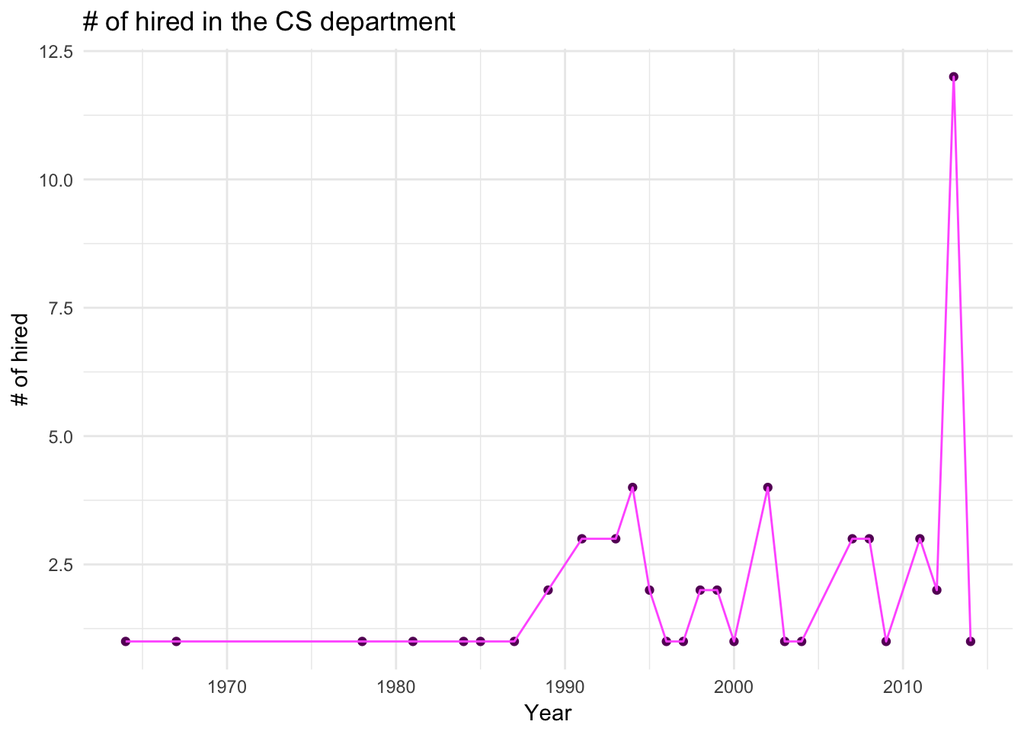

```r
hires <- filter(data, dept %in% c("Computer Science", "Statistics and Operations Res", "Mathematics", "Biostatistics", "School of Info & Libr Science", "Physics-Astronomy")) %>%mutate(hiredate = parse_datetime(hiredate, "%Y%m%d"),yr = year(hiredate)) %>% group_by(yr, dept) %>%summarise(N = n()) %>%ungroup

filter(hires, dept == "Computer Science") %>%ggplot(aes(x = yr, y = N)) + theme_minimal() + geom_point(color = "#660066") + geom_line(color = "#FF66FF") + ylab("# of hired") + xlab("Year") + ggtitle("# of hired in the CS department")
```

Now add STOR, Math, Biostatistics, SILS and Physics to the above plot

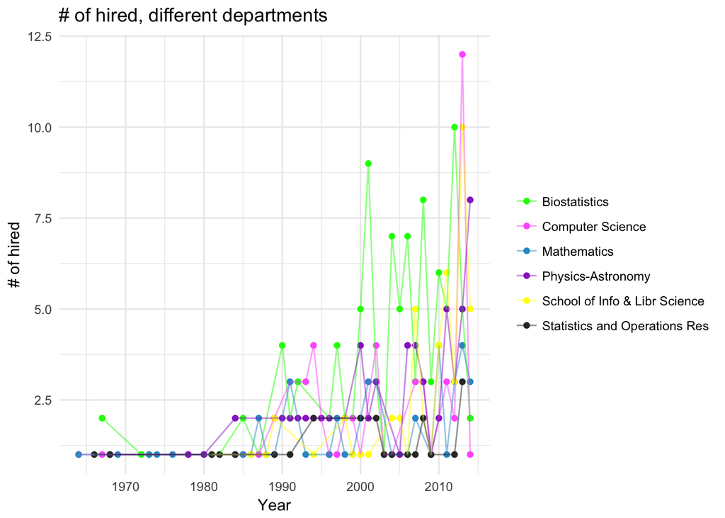

```r
ggplot(hires, aes(x = yr, y = N, color = dept)) + theme_minimal() +
  geom_point()+ geom_line(alpha = 0.5 ) + scale_color_manual(name = "", values = c("#00FF00", "#FF66FF", "#3399CC", "#9933CC", "#FFFF00", "#333333")) + ylab("# of hired") + xlab("Year") + ggtitle("# of hired, different departments")
```

# Open question

Examine the relationship between age and salary at UNC. You can interpret this however you like e.g.

- age can mean number of years employed at the university
- compare and contrast different departments

Requirements

- hand in a separate .Rmd document
  - load the data with read_csv(url(…)) like this script
- make 3 figures
  - a figure can be a visualization, print out of a data frame that you can created, the results of a statistical model/test (e.g. linear regression)
- display all code used
  - code should be commented
  - if you have a lot of functions you can put them in a separate .R script
- describe each figure
  - what is the figure (figure blah is a plot of foo vs. bar)
  - what is the upshot of the figure (figure blah shows that there is a strong relationship between foo and bar)
- write an explanation of your findings
  - a couple paragraphs
  - use proper grammar
  - your findings should be clear

# hints

Every question can be answered using: filter, arrange, select, mutate, summarize and group_by functions.

- here are two more dplyr tutorials: https://rpubs.com/justmarkham/dplyr-tutorial and https://www.coursera.org/learn/data-cleaning/home/week/3
- fte means full time employee